# USA House Election Results

Olivér Lubics

2023-12-14

## Introduction

This is my final project for the Statistical Programming PhD course at ELTE. I am going to explore the dataset of the U.S. House of Representatives election results. I chose this dataset because I’m interested in American politics, so I think that this project will also be a great opportunity for me to learn more about this topic.

The U.S. House of Representatives is the lower chamber of Congress, comprising 435 members representing districts across the nation. Its members are elected every two years, with each state allocated seats based on population size.

## Preparing for the analyses

First, I am loading the necessary packages and disabling scientific notation (I like to see the full numbers in the dataset).

```r
# Loading the necessary packages
library(tidyverse)
library(tidytuesdayR)
library(jtools)
library(broom)
library(olsrr)
library(ggfortify)
library(lmtest)

# Disabling scientific notation
options(scipen = 999)

# Setting the width of the plots
knitr::opts_chunk$set(fig.width = 10)
```

## Getting the data

At this step, I am doing data reading from the TidyTuesday GitHub repo, using the tidytuesdayR package.

```r
tuesdata <- tt_load('2023-11-07')
```

```
## --- Compiling #TidyTuesday Information for 2023-11-07 ----
```

```
## --- There is 1 file available ---
```

```
## --- Starting Download ---
```

```
## --- Download complete ---
```

```r
house_data <- tuesdata$house
```

## Exploratory data analysis

At this step, I am going to explore the dataset and create some plots.

```r
# Checking the structure of the data
str(house_data)
```

```
## spc_tbl_ [32,452 × 20] (S3: spec_tbl_df/tbl_df/tbl/data.frame)
##  $ year          : num [1:32452] 1976 1976 1976 1976 1976 ...
##  $ state         : chr [1:32452] "ALABAMA" "ALABAMA" "ALABAMA" "ALABAMA" ...
##  $ state_po      : chr [1:32452] "AL" "AL" "AL" "AL" ...
##  $ state_fips    : num [1:32452] 1 1 1 1 1 1 1 1 1 1 ...
##  $ state_cen     : num [1:32452] 63 63 63 63 63 63 63 63 63 63 ...
##  $ state_ic      : num [1:32452] 41 41 41 41 41 41 41 41 41 41 ...
##  $ office        : chr [1:32452] "US HOUSE" "US HOUSE" "US HOUSE" "US HOUSE" ...
##  $ district      : chr [1:32452] "001" "001" "001" "002" ...
##  $ stage         : chr [1:32452] "GEN" "GEN" "GEN" "GEN" ...
##  $ runoff        : logi [1:32452] FALSE FALSE FALSE FALSE FALSE FALSE ...
##  $ special       : logi [1:32452] FALSE FALSE FALSE FALSE FALSE FALSE ...
##  $ candidate     : chr [1:32452] "BILL DAVENPORT" "JACK EDWARDS" "WRITEIN" "J CAROLE KEAHEY" ...
##  $ party         : chr [1:32452] "DEMOCRAT" "REPUBLICAN" NA "DEMOCRAT" ...
##  $ writein       : logi [1:32452] FALSE FALSE TRUE FALSE FALSE TRUE ...
##  $ mode          : chr [1:32452] "TOTAL" "TOTAL" "TOTAL" "TOTAL" ...
##  $ candidatevotes: num [1:32452] 58906 98257 7 66288 90069 ...
##  $ totalvotes    : num [1:32452] 157170 157170 157170 156362 156362 ...
##  $ unofficial    : logi [1:32452] FALSE FALSE FALSE FALSE FALSE FALSE ...
##  $ version       : num [1:32452] 20230706 20230706 20230706 20230706 20230706 ...
##  $ fusion_ticket : logi [1:32452] FALSE FALSE FALSE FALSE FALSE FALSE ...
##  - attr(*, "spec")=
##   .. cols(
##   ..   year = col_double(),
##   ..   state = col_character(),
##   ..   state_po = col_character(),
##   ..   state_fips = col_double(),
##   ..   state_cen = col_double(),
##   ..   state_ic = col_double(),
##   ..   office = col_character(),
##   ..   district = col_character(),
##   ..   stage = col_character(),
##   ..   runoff = col_logical(),
##   ..   special = col_logical(),
##   ..   candidate = col_character(),
##   ..   party = col_character(),
##   ..   writein = col_logical(),
##   ..   mode = col_character(),
##   ..   candidatevotes = col_double(),
##   ..   totalvotes = col_double(),
##   ..   unofficial = col_logical(),
##   ..   version = col_double(),
##   ..   fusion_ticket = col_logical()
##   .. )
##  - attr(*, "problems")=<externalptr>
```

```r
# Checking the first rows of the data
head(house_data)
```

```
## # A tibble: 6 × 20
##    year state   state_po state_fips state_cen state_ic office   district stage
##   <dbl> <chr>   <chr>         <dbl>     <dbl>    <dbl> <chr>    <chr>    <chr>
## 1  1976 ALABAMA AL                1        63       41 US HOUSE 001      GEN
## 2  1976 ALABAMA AL                1        63       41 US HOUSE 001      GEN
## 3  1976 ALABAMA AL                1        63       41 US HOUSE 001      GEN
## 4  1976 ALABAMA AL                1        63       41 US HOUSE 002      GEN
## 5  1976 ALABAMA AL                1        63       41 US HOUSE 002      GEN
## 6  1976 ALABAMA AL                1        63       41 US HOUSE 002      GEN
## # ℹ 11 more variables: runoff <lgl>, special <lgl>, candidate <chr>,
## #   party <chr>, writein <lgl>, mode <chr>, candidatevotes <dbl>,
## #   totalvotes <dbl>, unofficial <lgl>, version <dbl>, fusion_ticket <lgl>
```

```r
# Checking the last rows of the data
tail(house_data)
```

```
## # A tibble: 6 × 20
##    year state   state_po state_fips state_cen state_ic office   district stage
##   <dbl> <chr>   <chr>         <dbl>     <dbl>    <dbl> <chr>    <chr>    <chr>
## 1  2022 WYOMING WY               56        83       68 US HOUSE 000      GEN
## 2  2022 WYOMING WY               56        83       68 US HOUSE 000      GEN
## 3  2022 WYOMING WY               56        83       68 US HOUSE 000      GEN
## 4  2022 WYOMING WY               56        83       68 US HOUSE 000      GEN
## 5  2022 WYOMING WY               56        83       68 US HOUSE 000      GEN
## 6  2022 WYOMING WY               56        83       68 US HOUSE 000      GEN
## # ℹ 11 more variables: runoff <lgl>, special <lgl>, candidate <chr>,
## #   party <chr>, writein <lgl>, mode <chr>, candidatevotes <dbl>,
## #   totalvotes <dbl>, unofficial <lgl>, version <dbl>, fusion_ticket <lgl>
```

So far, I can see that this dataset has the US House election results from 1976 to 2022 for each state.

```r
# Checking the number of missing values in each column
colSums(is.na(house_data))
```

```
##           year          state       state_po     state_fips      state_cen
##              0              0              0              0              0
##       state_ic         office       district          stage         runoff
##              0              0              0              0           8656
##        special      candidate          party        writein           mode
##              0              0           3858              0              0
## candidatevotes     totalvotes     unofficial        version  fusion_ticket
##              0              0              0              0              0
```

There are some missing values in the runoff and party coloumns. I don’t think that I will use the runoff coloumn later, but the missing values in the party coloumn could be a problem. I will look into this.

```r
# Checking the number of political parties in the elections. Sorting the parties by the number of elections they participated in.
house_data %>%
  count(party, sort = TRUE)
```

```
## # A tibble: 478 × 2
##    party                n
##    <chr>            <int>
##  1 DEMOCRAT          9908
##  2 REPUBLICAN        9705
##  3 <NA>              3858
##  4 LIBERTARIAN       2769
##  5 INDEPENDENT       1217
##  6 CONSERVATIVE       668
##  7 GREEN              513
##  8 NATURAL LAW        371
##  9 WORKING FAMILIES   283
## 10 LIBERAL            266
## # ℹ 468 more rows
```

It’s really interesting to see that there are 478 parties that participated in the elections, while there are only 2 major parties in the US (Democratic and Republican). For simplicity, I will only focus on these two parties. Filtering will also solve the problem of missing values in the party coloumn.

```r
# Removing the parties that are not Democratic or Republican
house_data_cleaned <- house_data %>%
  filter(party == "DEMOCRAT" | party == "REPUBLICAN")
```

## Exploratory data analysis plotting

### Plotting the percentage of votes by year and party

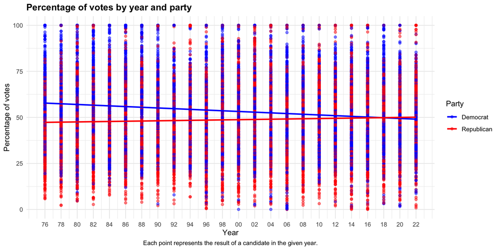

```r
# Adding a new column that shows the percentage of votes for each candidate and removing the all uppercase format from the party names
house_data_cleaned <- house_data_cleaned %>%
  mutate(percent_of_votes = (candidatevotes / totalvotes) * 100) %>%
   mutate(party = str_to_title(tolower(party)))

# Plotting the percentage of votes by year and party. I am setting the color of the points and the lines manually, because I want the 2 parties to have their traditional colors.
house_data_cleaned %>%
  ggplot() +
  aes(x = year, y = percent_of_votes, color = party) +
  geom_point(alpha = 0.5) +
  geom_smooth(method = "lm", se = FALSE) +
  scale_color_manual(values = c("Democrat" = "blue", "Republican" = "red")) +
  labs(title = "Percentage of votes by year and party",
       x = "Year",
       y = "Percentage of votes",
       color = "Party",
       caption = "Each point represents the result of a candidate in the given year.") +
  scale_x_continuous(
    breaks = unique(house_data_cleaned$year),
    labels = function(x) substring(x, nchar(x) - 1)
  ) +
  theme_minimal() +
  theme(
    plot.title = element_text(face = "bold"),
    plot.caption = element_text(hjust = 0.5))
```

It’s interesting to see that the percentage of votes for the Democratic party’s candidates has been decreasing since 1976, while the percentage of votes for the Republican party has been increasing since then. However, this result might be misleading when compared to actual election outcomes. In any case, the results of the two parties’ candidates are generally quite close.

### Plotting the number of votes by year and party

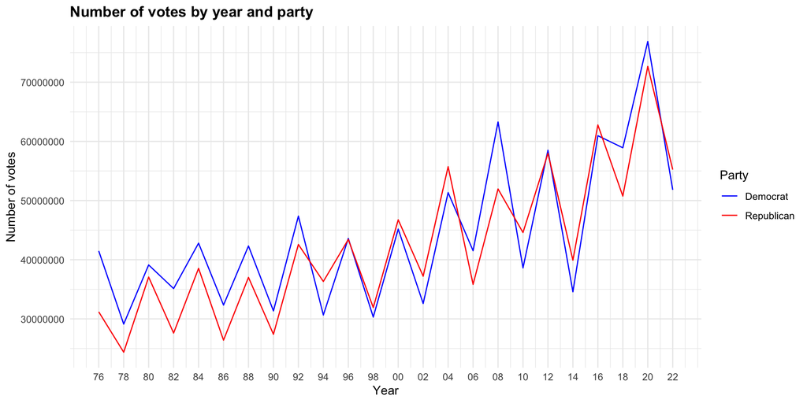

```r
# Plotting the number of votes by year and party on a line plot
house_data_cleaned %>%
  group_by(year, party) %>%
  summarise(total_votes = sum(candidatevotes)) %>%
  ggplot() +
  aes(x = year, y = total_votes, color = party) +
  geom_line() +
  scale_color_manual(values = c("Democrat" = "blue", "Republican" = "red")) +
  labs(title = "Number of votes by year and party",
       x = "Year",
       y = "Number of votes",
       color = "Party") +
  scale_x_continuous(
    breaks = unique(house_data_cleaned$year),
    labels = function(x) substring(x, nchar(x) - 1)
  ) +
  theme_minimal() +
  theme(
    plot.title = element_text(face = "bold"),
    plot.caption = element_text(hjust = 0.5)
  )
```

It’s interesting to see how much voter turnout varies the years. I think that big variation could be caused by the fact that the US House elections are held every two years, and the turnout is could be higher, when the presidential election is also happening in the same year. I will look into this.